# Attrition Study - Case Study 2

# Linear Regression for Monthly Salary

```r
#first pass model with all variables

linear1 <- lm(MonthlyIncome ~., data = trainSet)
summary(linear1)
```

```
##
## Call:
## lm(formula = MonthlyIncome ~ ., data = trainSet)
##
## Residuals:
##     Min      1Q  Median      3Q     Max
## -2803.5  -593.3   -49.8   540.2  3926.5
##
## Coefficients:
##                                    Estimate Std. Error t value Pr(>|t|)
## (Intercept)                       8.113e+03  8.764e+02   9.257  < 2e-16 ***
## Age                              -8.125e+00  6.720e+00  -1.209  0.22720
## AttritionYes                     -3.558e+01  1.433e+02  -0.248  0.80394
## BusinessTravelTravel_Frequently   2.629e+02  1.689e+02   1.557  0.12011
## BusinessTravelTravel_Rarely       3.691e+02  1.427e+02   2.587  0.00995 **
## DailyRate                         2.173e-01  1.109e-01   1.958  0.05074 .
## DepartmentResearch & Development -1.201e+02  6.393e+02  -0.188  0.85106
## DepartmentSales                  -4.198e+02  6.631e+02  -0.633  0.52699
## DistanceFromHome                  5.510e-01  5.529e+00   0.100  0.92066
## Education.L                      -2.008e+02  2.115e+02  -0.950  0.34280
## Education.Q                      -1.987e+02  1.783e+02  -1.114  0.26564
## Education.C                      -2.673e+02  1.303e+02  -2.051  0.04075 *
## Education^4                      -1.121e+02  9.079e+01  -1.235  0.21746
## EducationFieldLife Sciences      -1.693e+01  5.313e+02  -0.032  0.97460
## EducationFieldMarketing          -4.990e+01  5.559e+02  -0.090  0.92851
## EducationFieldMedical            -9.922e+01  5.318e+02  -0.187  0.85206
## EducationFieldOther              -3.098e+02  5.599e+02  -0.553  0.58031
## EducationFieldTechnical Degree   -1.674e+02  5.486e+02  -0.305  0.76044
## EnvironmentSatisfaction.L        -8.660e+01  9.051e+01  -0.957  0.33914
## EnvironmentSatisfaction.Q         1.463e+01  9.069e+01   0.161  0.87191
## EnvironmentSatisfaction.C        -1.016e+02  9.177e+01  -1.107  0.26869
## GenderMale                        1.466e+02  9.005e+01   1.628  0.10404
## HourlyRate                       -9.006e-02  2.229e+00  -0.040  0.96778
## JobInvolvement2                  -1.724e+02  2.116e+02  -0.814  0.41580
## JobInvolvement3                  -2.359e+02  2.039e+02  -1.157  0.24776
## JobInvolvement4                  -1.091e+02  2.415e+02  -0.452  0.65168
## JobLevel.L                        9.054e+03  3.513e+02  25.777  < 2e-16 ***
## JobLevel.Q                        5.419e+02  1.894e+02   2.862  0.00438 **
## JobLevel.C                       -6.248e+02  1.662e+02  -3.759  0.00019 ***
## JobLevel^4                        3.869e+01  1.406e+02   0.275  0.78333
```

[output cut: 37 more lines]

```
## TrainingTimesLastYear5           -1.746e+02  3.152e+02  -0.554  0.57983
## TrainingTimesLastYear6           -6.246e+01  3.443e+02  -0.181  0.85612
## WorkLifeBalance.L                 6.779e+01  1.532e+02   0.443  0.65823
## WorkLifeBalance.Q                -2.369e+02  1.252e+02  -1.892  0.05902 .
## WorkLifeBalance.C                 4.786e+01  8.935e+01   0.536  0.59244
## YearsAtCompany                    1.600e+00  2.146e+01   0.075  0.94059
## YearsInCurrentRole                4.984e+00  2.350e+01   0.212  0.83208
## YearsSinceLastPromotion           1.397e+01  1.983e+01   0.705  0.48141
## YearsWithCurrManager              3.600e+00  2.192e+01   0.164  0.86960
## ---
## Signif. codes:  0 '***' 0.001 '**' 0.01 '*' 0.05 '.' 0.1 ' ' 1
##
## Residual standard error: 1019 on 516 degrees of freedom
## Multiple R-squared:  0.9521, Adjusted R-squared:  0.9451
## F-statistic: 136.6 on 75 and 516 DF,  p-value: < 2.2e-16
```

Our linear regression model using all variables gives an Adj R-squared of 0.95 and RMSE of $1019.

```r
pred_linear1 <- predict(linear1, newdata = testSet)
postResample(testSet$MonthlyIncome,pred_linear1)
```

```
##        RMSE    Rsquared         MAE
## 1040.827405    0.938808  800.753949
```

Our test set performance is also equally good. However, these values make me suspect some over-fitting of the data. Let’s check residuals.

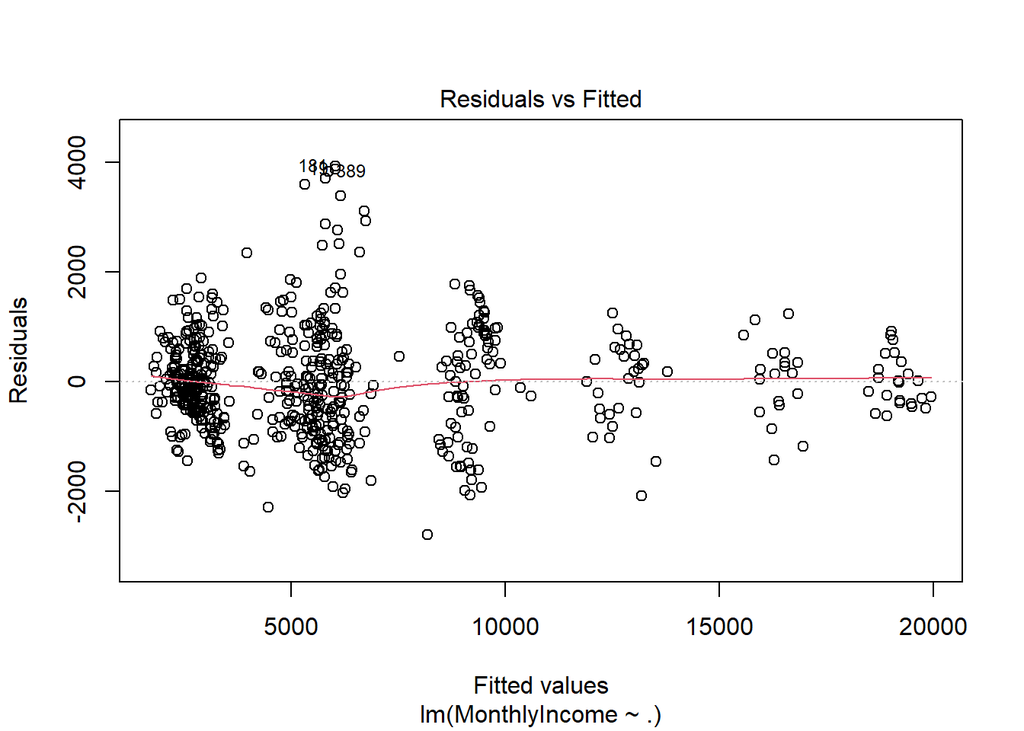

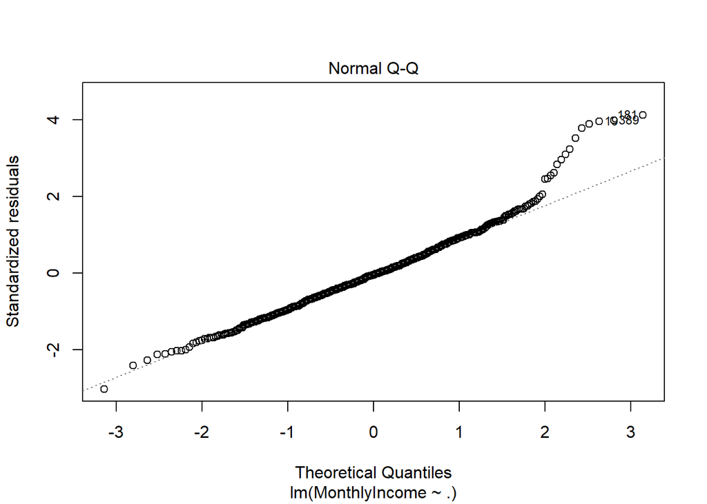

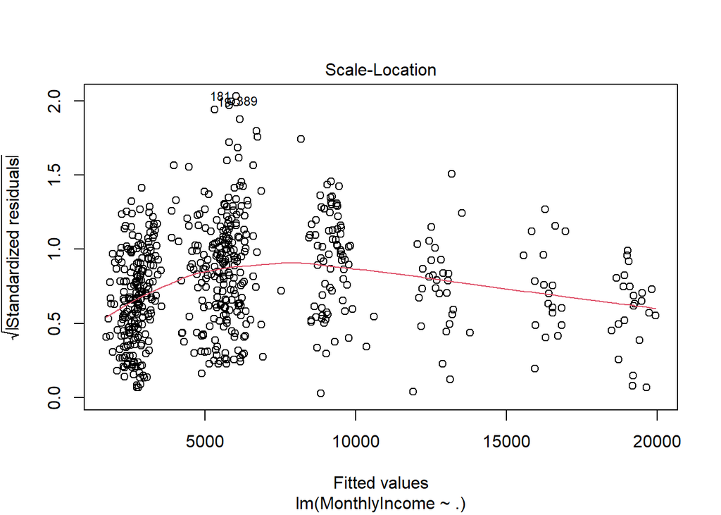

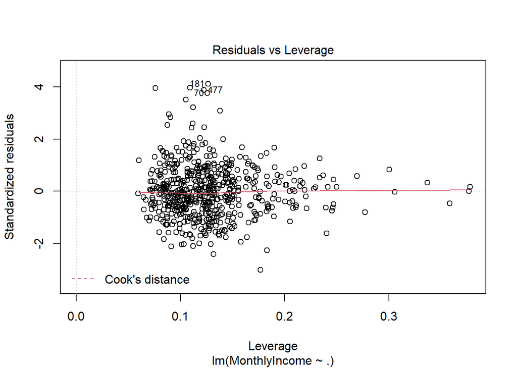

```r
plot(linear1)
```

Residuals look OK, but we know that MonthlyIncome is skewed. Let’s re-run with log transform to see if our residuals look better. However, we are building this purely as a predictive model, so meeting our assumptions is not really important versus if we were developing a purely explanatory model.

```r
linear2 <- lm(log(MonthlyIncome) ~., data = trainSet)
summary(linear2)
```

```
##
## Call:
## lm(formula = log(MonthlyIncome) ~ ., data = trainSet)
##
## Residuals:
##      Min       1Q   Median       3Q      Max
## -0.77957 -0.12130 -0.00414  0.11421  0.61517
##
## Coefficients:
##                                    Estimate Std. Error t value Pr(>|t|)
## (Intercept)                       8.701e+00  1.823e-01  47.724  < 2e-16 ***
## Age                              -1.202e-03  1.398e-03  -0.860 0.390447
## AttritionYes                     -3.408e-02  2.980e-02  -1.144 0.253300
## BusinessTravelTravel_Frequently   6.938e-02  3.513e-02   1.975 0.048777 *
## BusinessTravelTravel_Rarely       8.629e-02  2.968e-02   2.907 0.003804 **
## DailyRate                         2.648e-05  2.308e-05   1.147 0.251719
## DepartmentResearch & Development  2.729e-02  1.330e-01   0.205 0.837491
## DepartmentSales                  -8.162e-03  1.379e-01  -0.059 0.952838
## DistanceFromHome                  9.618e-04  1.150e-03   0.836 0.403440
## Education.L                      -4.705e-02  4.400e-02  -1.070 0.285339
## Education.Q                      -5.415e-02  3.708e-02  -1.460 0.144820
## Education.C                      -5.342e-02  2.710e-02  -1.971 0.049258 *
## Education^4                      -3.148e-02  1.889e-02  -1.667 0.096112 .
## EducationFieldLife Sciences      -6.708e-02  1.105e-01  -0.607 0.544156
## EducationFieldMarketing          -6.271e-02  1.156e-01  -0.542 0.587883
## EducationFieldMedical            -8.299e-02  1.106e-01  -0.750 0.453465
## EducationFieldOther              -1.259e-01  1.165e-01  -1.081 0.280236
## EducationFieldTechnical Degree   -1.267e-01  1.141e-01  -1.110 0.267478
## EnvironmentSatisfaction.L        -2.549e-02  1.883e-02  -1.354 0.176383
## EnvironmentSatisfaction.Q         2.271e-02  1.887e-02   1.204 0.229206
## EnvironmentSatisfaction.C        -1.567e-02  1.909e-02  -0.821 0.412019
## GenderMale                        3.266e-02  1.873e-02   1.743 0.081867 .
## HourlyRate                       -4.306e-05  4.636e-04  -0.093 0.926029
## JobInvolvement2                  -2.123e-02  4.402e-02  -0.482 0.629763
## JobInvolvement3                  -2.994e-02  4.241e-02  -0.706 0.480576
## JobInvolvement4                   1.010e-02  5.024e-02   0.201 0.840817
## JobLevel.L                        1.045e+00  7.307e-02  14.305  < 2e-16 ***
## JobLevel.Q                       -2.590e-01  3.939e-02  -6.576 1.18e-10 ***
## JobLevel.C                       -9.423e-03  3.458e-02  -0.273 0.785343
## JobLevel^4                        3.011e-02  2.925e-02   1.029 0.303897
```

[output cut: 37 more lines]

```
## TrainingTimesLastYear5           -5.590e-02  6.557e-02  -0.853 0.394299
## TrainingTimesLastYear6           -6.593e-03  7.162e-02  -0.092 0.926692
## WorkLifeBalance.L                 1.622e-02  3.186e-02   0.509 0.610816
## WorkLifeBalance.Q                -4.484e-02  2.604e-02  -1.722 0.085751 .
## WorkLifeBalance.C                 1.418e-02  1.859e-02   0.763 0.445729
## YearsAtCompany                   -1.621e-03  4.464e-03  -0.363 0.716692
## YearsInCurrentRole                8.528e-03  4.888e-03   1.745 0.081603 .
## YearsSinceLastPromotion          -7.911e-04  4.125e-03  -0.192 0.847994
## YearsWithCurrManager              2.688e-03  4.560e-03   0.590 0.555754
## ---
## Signif. codes:  0 '***' 0.001 '**' 0.01 '*' 0.05 '.' 0.1 ' ' 1
##
## Residual standard error: 0.2121 on 516 degrees of freedom
## Multiple R-squared:  0.9045, Adjusted R-squared:  0.8906
## F-statistic: 65.14 on 75 and 516 DF,  p-value: < 2.2e-16
```

Our R-squared decreases a bit, and we have to recalculate our RMSE since it’s on the log scale, but let’s check residuals.

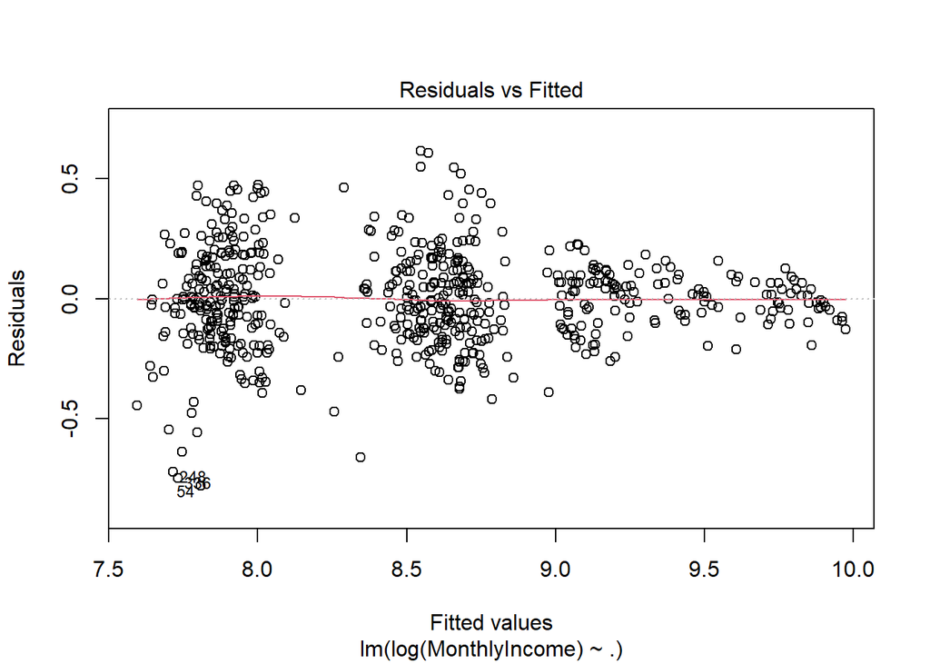

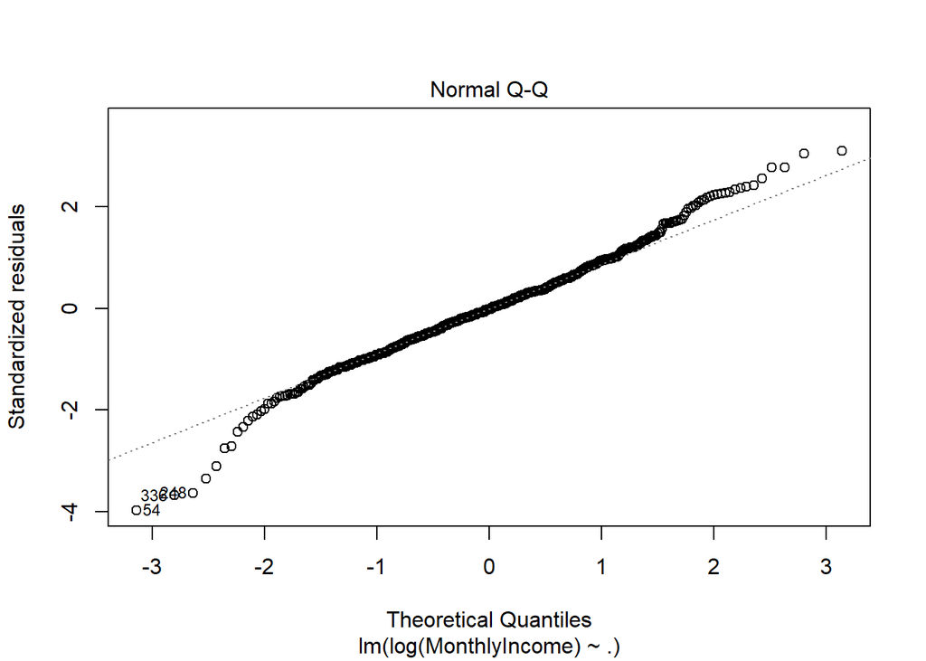

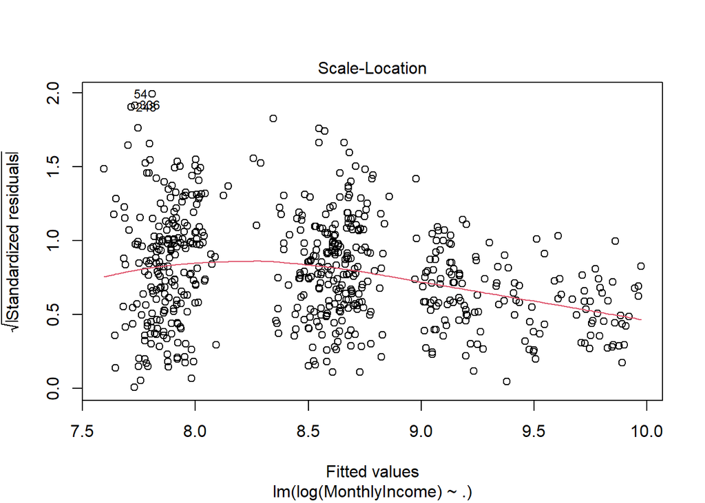

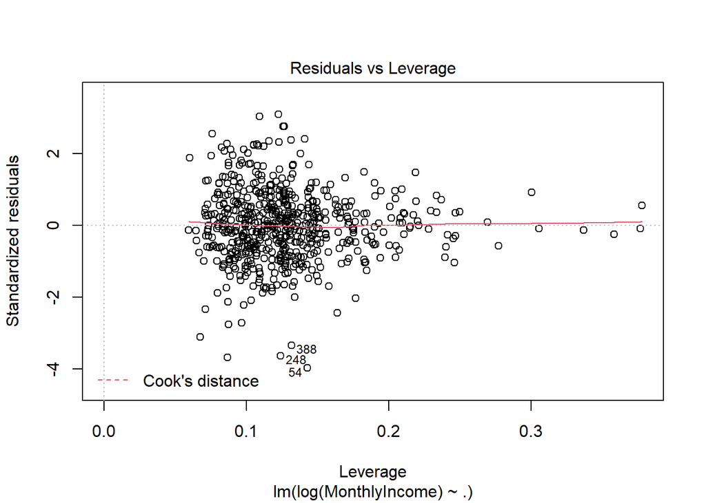

```r
plot(linear2)
```

Residuals look a little better. Since our goal is prediction, let’s proceed with this model including all variables as it yields good performance.

```r
#predict on test set and check performance
predict_lm <- predict(linear2, newdata = testSet)

postResample(exp(predict_lm), testSet$MonthlyIncome)
```

```
##         RMSE     Rsquared          MAE
## 1123.8220411    0.9294559  840.1440548
```

We have good performance on our test set as well, with RMSE < $3000 at $1123 and our Rsquared at 0.929.

### Save Linear Model

```r
final_linear <- linear2
```

# Make and Save Predictions

## Attrition Classifier

```r
#load in data
attrition <- read_csv(here::here("data", "CaseStudy2CompSet No Attrition.csv"))
#pre-process to match training set

# Check for missing values
tibble(variable = names(colSums(is.na(attrition))),
       missing = colSums(is.na(attrition))) %>%
  gt() %>%
  tab_header(title = "Missing Values in Data")
```

Missing Values in Data

| variable | missing |
| --- | --- |
| ID | 0 |
| Age | 0 |
| BusinessTravel | 0 |
| DailyRate | 0 |
| Department | 0 |
| DistanceFromHome | 0 |
| Education | 0 |
| EducationField | 0 |
| EmployeeCount | 0 |
| EmployeeNumber | 0 |
| EnvironmentSatisfaction | 0 |
| Gender | 0 |
| HourlyRate | 0 |
| JobInvolvement | 0 |
| JobLevel | 0 |
| JobRole | 0 |
| JobSatisfaction | 0 |
| MaritalStatus | 0 |
| MonthlyIncome | 0 |
| MonthlyRate | 0 |
| NumCompaniesWorked | 0 |
| Over18 | 0 |
| OverTime | 0 |
| PercentSalaryHike | 0 |
| PerformanceRating | 0 |
| RelationshipSatisfaction | 0 |
| StandardHours | 0 |
| StockOptionLevel | 0 |
| TotalWorkingYears | 0 |
| TrainingTimesLastYear | 0 |
| WorkLifeBalance | 0 |
| YearsAtCompany | 0 |
| YearsInCurrentRole | 0 |
| YearsSinceLastPromotion | 0 |
| YearsWithCurrManager | 0 |

```r
#have to keep ID in for our prediction comparison, will exclude when running model
```

```r
#update all characters to factors
attrition[sapply(attrition, is.character)] <- lapply(attrition[sapply(attrition, is.character)],
                                       as.factor)

#str(attrition)
```

```r
#update other groups to factors
attrition[cols] <- lapply(attrition[cols], factor)

#str(attrition)
```

```r
attrition$Education <- factor(attrition$Education, ordered = TRUE)
attrition$EnvironmentSatisfaction <- factor(attrition$EnvironmentSatisfaction, ordered = TRUE)
attrition$JobLevel <- factor(attrition$JobLevel, ordered = TRUE)
attrition$JobSatisfaction <- factor(attrition$JobSatisfaction, ordered = TRUE)
attrition$PerformanceRating <- factor(attrition$PerformanceRating, ordered = TRUE)
attrition$RelationshipSatisfaction <- factor(attrition$RelationshipSatisfaction, ordered = TRUE)
attrition$WorkLifeBalance <- factor(attrition$WorkLifeBalance, ordered = TRUE)

#str(attrition)
```

```r
#remove unnecessary values, employee count, over18, and standard hours
attrition <- attrition %>% dplyr::select(-c(EmployeeCount, Over18, StandardHours, EmployeeNumber))
```

## Make Predictions

```r
#predict on test set and check performance
predict_attrition <- predict(final_class, newdata = attrition[,2:31])

#join back to original dataset
attrition <- attrition %>% mutate(Attrition = predict_attrition)

#remove all columns except ID
attrition <- attrition %>% select(c("ID","Attrition"))

#save file
Case2PredictionsBall_Attrition  <- write.csv(attrition, "Case2PredictionsBall_Attrition.csv", row.names = FALSE)
```

## Salary Predictor

```r
#load in data
salary <- read_csv(here::here("data", "CaseStudy2CompSet No Salary.csv"))
#pre-process to match training set

# Check for missing values
tibble(variable = names(colSums(is.na(salary))),
       missing = colSums(is.na(salary))) %>%
  gt() %>%
  tab_header(title = "Missing Values in Data")
```

Missing Values in Data

| variable | missing |
| --- | --- |
| ID | 0 |
| Age | 0 |
| Attrition | 0 |
| BusinessTravel | 0 |
| DailyRate | 0 |
| Department | 0 |
| DistanceFromHome | 0 |
| Education | 0 |
| EducationField | 0 |
| EmployeeCount | 0 |
| EmployeeNumber | 0 |
| EnvironmentSatisfaction | 0 |
| Gender | 0 |
| HourlyRate | 0 |
| JobInvolvement | 0 |
| JobLevel | 0 |
| JobRole | 0 |
| JobSatisfaction | 0 |
| MaritalStatus | 0 |
| MonthlyRate | 0 |
| NumCompaniesWorked | 0 |
| Over18 | 0 |
| OverTime | 0 |
| PercentSalaryHike | 0 |
| PerformanceRating | 0 |
| RelationshipSatisfaction | 0 |
| StandardHours | 0 |
| StockOptionLevel | 0 |
| TotalWorkingYears | 0 |
| TrainingTimesLastYear | 0 |
| WorkLifeBalance | 0 |
| YearsAtCompany | 0 |
| YearsInCurrentRole | 0 |
| YearsSinceLastPromotion | 0 |
| YearsWithCurrManager | 0 |

```r
#have to keep ID in for our prediction comparison, will exclude when running model
```

```r
salary[sapply(salary, is.character)] <- lapply(salary[sapply(salary, is.character)],
                                       as.factor)

#update other groups to factors
salary[cols] <- lapply(salary[cols], factor)

salary$Education <- factor(salary$Education, ordered = TRUE)
salary$EnvironmentSatisfaction <- factor(salary$EnvironmentSatisfaction, ordered = TRUE)
salary$JobLevel <- factor(salary$JobLevel, ordered = TRUE)
salary$JobSatisfaction <- factor(salary$JobSatisfaction, ordered = TRUE)
salary$PerformanceRating <- factor(salary$PerformanceRating, ordered = TRUE)
salary$RelationshipSatisfaction <- factor(salary$RelationshipSatisfaction, ordered = TRUE)
salary$WorkLifeBalance <- factor(salary$WorkLifeBalance, ordered = TRUE)

#str(salary)

#remove unnecessary values, employee count, over18, and standard hours
salary <- salary %>% dplyr::select(-c(EmployeeCount, Over18, StandardHours, EmployeeNumber))
```

## Make Predictions

```r
#predict on test set and check performance
predict_salary <- predict(final_linear, newdata = salary[,2:31])

#join back to original dataset
salary <- salary %>% mutate(MonthlyIncome = exp(predict_salary))

#remove all columns except ID
salary <- salary %>% select(c("ID","MonthlyIncome"))

#save file
Case2PredictionsBall_Salary  <- write.csv(salary, "Case2PredictionsBall_Salary.csv", row.names = FALSE)
```

# Video

[Video](https://youtu.be/E7-DQ4fGkkg)